# analisis

Sebastian Agudelo Jimenez

22/3/2021

```r
#librerias
library(readxl)
library(tidyverse)
library(ggplot2)
```

# Vrbls. de Caracteristicas y composicion del hogar

```r
cch <- read.csv("Caracteristicas y composicion del hogar.csv", sep = ";")
nombres <- names(cch)
nombres[1]<-"DIRECTORIO"
colnames(cch)<- nombres
cch$DIRECTORIO<- as.factor(cch$DIRECTORIO)
#sacando los hijos
hijos <- cch %>% filter(P6051==3) %>% count(DIRECTORIO)
hijosxcch <- merge(x = hijos, y = cch, all= TRUE)
hijosxcch$n[is.na(hijosxcch$n)] <- 0
#sacando la cabeza del hogar
cabh <- cch %>% filter(P6051==1)
hijoscab<- merge(x = hijos, y = cabh, all= TRUE)
hijoscab$n[is.na(hijoscab$n)] <- 0
hijoscabx<- hijoscab[,1:2]
```

## P6083: Madre en el hogar

Corresponde a la pregunta: **La madre de ____ ¿vive en este hogar?** Las respuestas son: 1. Sí 2. No 3. Fallecida

```r
tapply(hijoscab$n, hijoscab$P6083, summary)
```

```
## $`1`
##    Min. 1st Qu.  Median    Mean 3rd Qu.    Max.
##  0.0000  0.0000  1.0000  0.9789  2.0000  9.0000
##
## $`2`
##    Min. 1st Qu.  Median    Mean 3rd Qu.    Max.
##   0.000   0.000   1.000   1.326   2.000  13.000
##
## $`3`
##    Min. 1st Qu.  Median    Mean 3rd Qu.    Max.
##  0.0000  0.0000  0.0000  0.8619  1.0000 11.0000
```

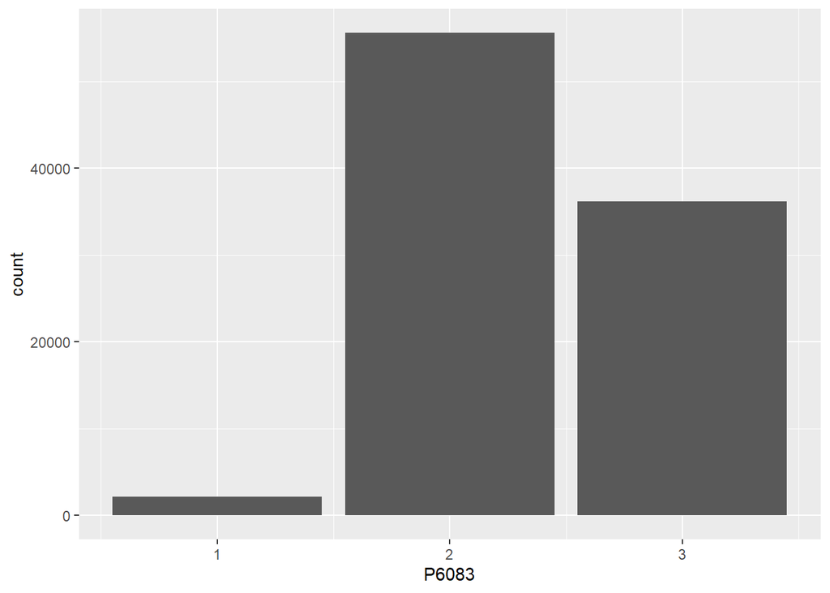

```r
ggplot(hijoscab, aes(x=P6083)) + geom_bar()
```

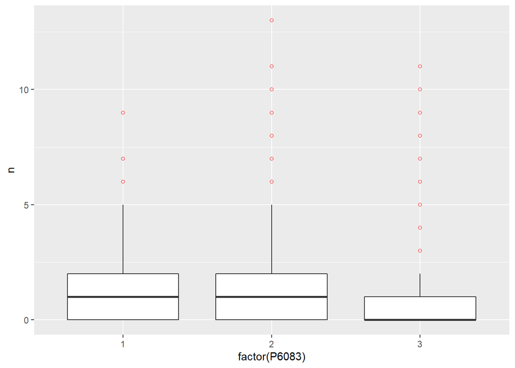

```r
ggplot(hijoscab, aes(x = factor(P6083), y = n)) + geom_boxplot(outlier.colour = "red", outlier.shape = 1)
```

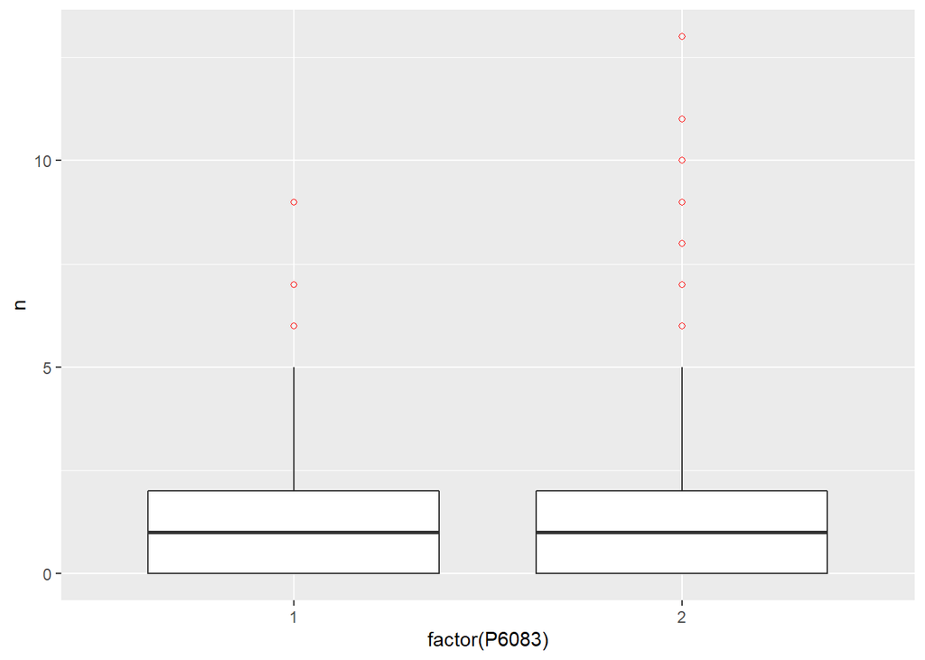

```r
href <- hijoscab
href$P6083[href$P6083==3] <- 2
ggplot(href, aes(x = factor(P6083), y = n)) + geom_boxplot(outlier.colour = "red", outlier.shape = 1)
```

no se considera?

## P6088: Nivel de educación de la madre

Corresponde a la pregunta: **Cuál es o fue el nivel de educación más alto alcanzado por la madre de …?** Las respuestas son: 1. Algunos años de primaria 2. Toda la primaria 3. Algunos años de secundaria 4. Toda la secundaria 5. Uno o mas años de técnica o tecnológica 6. Técnica o tecnológica completa 7. Uno o mas años de universidad 8. Universitaria completa 9. Ninguno 10. No sabe

```r
hijoscabna<- hijoscab[!is.na(hijoscab$P6088),]
tapply(hijoscabna$n, hijoscabna$P6088, summary)
```

```
## $`1`
##    Min. 1st Qu.  Median    Mean 3rd Qu.    Max.
##   0.000   0.000   1.000   1.161   2.000  13.000
##
## $`2`
##    Min. 1st Qu.  Median    Mean 3rd Qu.    Max.
##   0.000   0.000   1.000   1.159   2.000  10.000
##
## $`3`
##    Min. 1st Qu.  Median    Mean 3rd Qu.    Max.
##   0.000   0.000   1.000   1.104   2.000   9.000
##
## $`4`
##    Min. 1st Qu.  Median    Mean 3rd Qu.    Max.
##   0.000   0.000   1.000   1.018   2.000  13.000
##
## $`5`
##    Min. 1st Qu.  Median    Mean 3rd Qu.    Max.
##  0.0000  0.0000  1.0000  0.9579  1.0000  4.0000
##
## $`6`
##    Min. 1st Qu.  Median    Mean 3rd Qu.    Max.
##   0.000   0.000   1.000   0.912   2.000   5.000
##
## $`7`
##    Min. 1st Qu.  Median    Mean 3rd Qu.    Max.
##   0.000   0.000   0.000   0.784   1.000   5.000
##
## $`8`
##    Min. 1st Qu.  Median    Mean 3rd Qu.    Max.
##  0.0000  0.0000  0.0000  0.7876  1.0000  6.0000
##
## $`9`
##    Min. 1st Qu.  Median    Mean 3rd Qu.    Max.
##   0.000   0.000   1.000   1.197   2.000  11.000
##
## $`10`
##    Min. 1st Qu.  Median    Mean 3rd Qu.    Max.
##   0.000   0.000   1.000   1.112   2.000  10.000
```

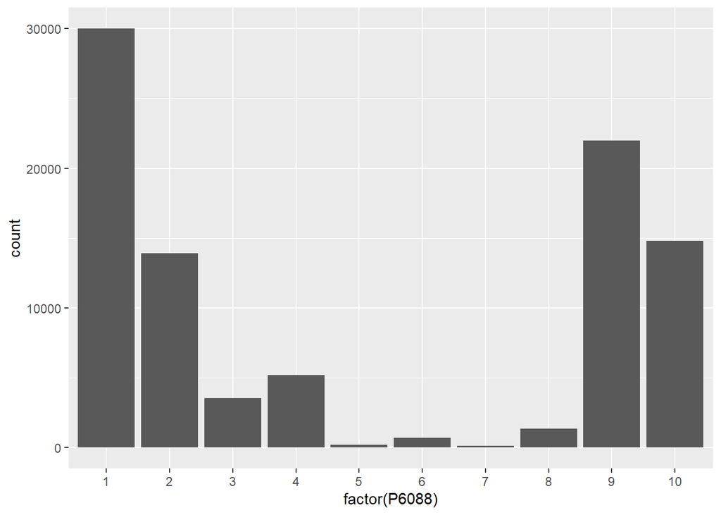

```r
ggplot(hijoscabna, aes(x=factor(P6088))) + geom_bar()
```

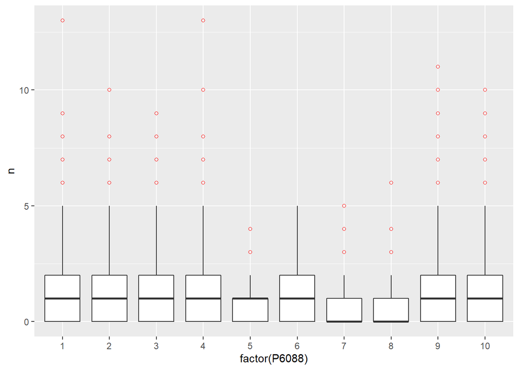

```r
ggplot(hijoscabna, aes(x = factor(P6088), y = n)) + geom_boxplot(outlier.colour = "red", outlier.shape = 1)
```

no se considera

## P2057: Se considera campesino

```r
hijoscabna<- hijoscab[!is.na(hijoscab$P2057),]
tapply(hijoscabna$n, hijoscabna$P2057, summary)
```

```
## $`1`
##    Min. 1st Qu.  Median    Mean 3rd Qu.    Max.
##   0.000   0.000   1.000   1.138   2.000  11.000
##
## $`2`
##    Min. 1st Qu.  Median    Mean 3rd Qu.    Max.
##   0.000   0.000   1.000   1.141   2.000  13.000
##
## $`9`
##    Min. 1st Qu.  Median    Mean 3rd Qu.    Max.
##   0.000   0.000   1.000   1.074   2.000   5.000
```

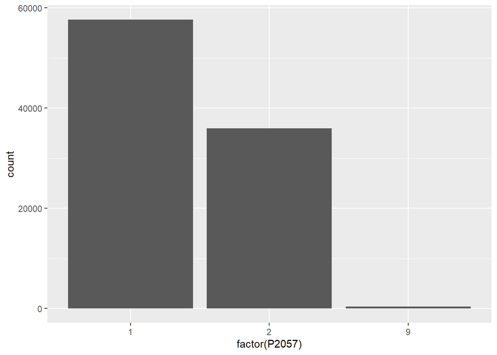

```r
ggplot(hijoscabna, aes(x=factor(P2057))) + geom_bar()
```

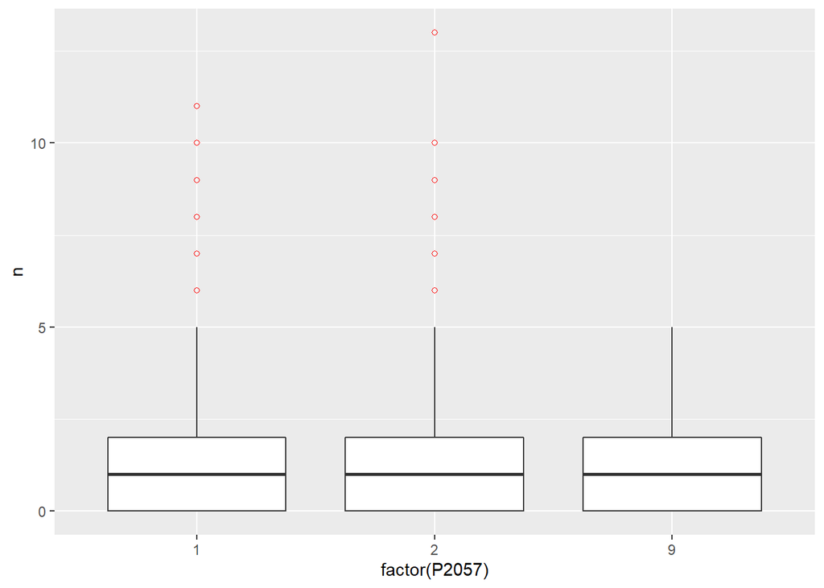

```r
ggplot(hijoscabna, aes(x = factor(P2057), y = n)) + geom_boxplot(outlier.colour = "red", outlier.shape = 1)
```

no se considera

## P1897: Satisfacción con nivel de salud

Corresponde a la pregunta: **En general, qué tan satisfecho(a) se siente … con su salud actualmente?** Las respuestas son: 10. Totalmente satisfecho(a) 9. 8. 7. 6. 5. 4. 3. 2. 1. 0.Totalmente insatisfecho(a)

```r
hijoscabna<- hijoscab[!is.na(hijoscab$P1897),]
tapply(hijoscabna$n, hijoscabna$P1897, summary)
```

```
## $`0`
##    Min. 1st Qu.  Median    Mean 3rd Qu.    Max.
##   0.000   0.000   1.000   1.037   2.000   7.000
##
## $`1`
##    Min. 1st Qu.  Median    Mean 3rd Qu.    Max.
##  0.0000  0.0000  1.0000  0.9969  2.0000  5.0000
##
## $`2`
##    Min. 1st Qu.  Median    Mean 3rd Qu.    Max.
##   0.000   0.000   1.000   1.048   2.000   7.000
##
## $`3`
##    Min. 1st Qu.  Median    Mean 3rd Qu.    Max.
##  0.0000  0.0000  1.0000  0.9708  2.0000  7.0000
##
## $`4`
##    Min. 1st Qu.  Median    Mean 3rd Qu.    Max.
##   0.000   0.000   1.000   1.011   2.000  10.000
##
## $`5`
##    Min. 1st Qu.  Median    Mean 3rd Qu.    Max.
##    0.00    0.00    1.00    1.04    2.00    9.00
##
## $`6`
##    Min. 1st Qu.  Median    Mean 3rd Qu.    Max.
##   0.000   0.000   1.000   1.084   2.000  13.000
##
## $`7`
##    Min. 1st Qu.  Median    Mean 3rd Qu.    Max.
##   0.000   0.000   1.000   1.134   2.000  11.000
##
## $`8`
##    Min. 1st Qu.  Median    Mean 3rd Qu.    Max.
##    0.00    0.00    1.00    1.19    2.00   13.00
##
## $`9`
##    Min. 1st Qu.  Median    Mean 3rd Qu.    Max.
##   0.000   0.000   1.000   1.196   2.000   9.000
##
## $`10`
##    Min. 1st Qu.  Median    Mean 3rd Qu.    Max.
##   0.000   0.000   1.000   1.146   2.000   9.000
```

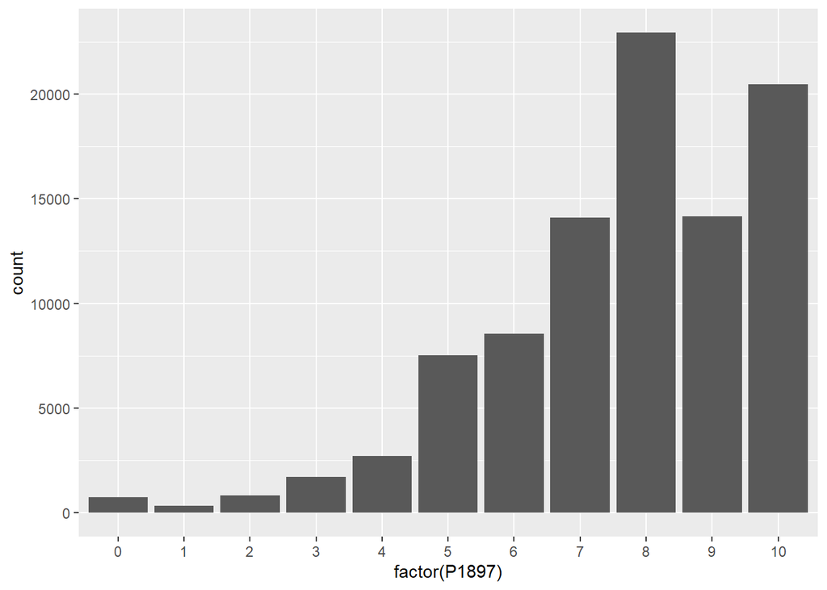

```r
ggplot(hijoscabna, aes(x=factor(P1897))) + geom_bar()
```

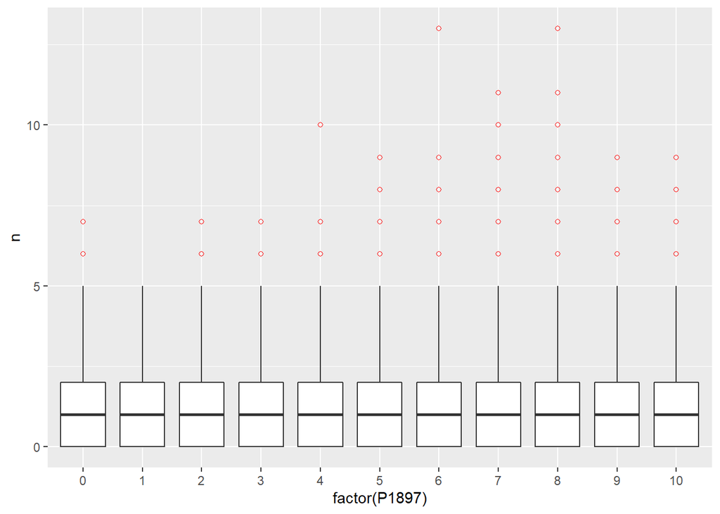

```r
ggplot(hijoscabna, aes(x = factor(P1897), y = n)) + geom_boxplot(outlier.colour = "red", outlier.shape = 1)
```

no se considera

# Vrbls. de Educación

```r
educ <- read.csv("Educación.csv", sep = ";")
nombres <- names(educ)
nombres[1]<-"DIRECTORIO"
colnames(educ)<- nombres
educ$DIRECTORIO<- as.factor(educ$DIRECTORIO)
hijosxeduc <- merge(x = hijoscabx, y = educ)
```

## P1101: Jornada de estudio

Corresponde a la pregunta: **¿En qué jornada estudia …?** Las respuestas son: 1. Mañana 2. Tarde 3. Noche 4. Única o completa 5. Fin de semana

```r
hijosxeducna<- hijosxeduc[!is.na(hijosxeduc$P1101),]
tapply(hijosxeducna$n, hijosxeducna$P1101, summary)
```

```
## $`1`
##    Min. 1st Qu.  Median    Mean 3rd Qu.    Max.
##   0.000   1.000   2.000   2.417   3.000  13.000
##
## $`2`
##    Min. 1st Qu.  Median    Mean 3rd Qu.    Max.
##   0.000   1.000   2.000   2.302   3.000  11.000
##
## $`3`
##    Min. 1st Qu.  Median    Mean 3rd Qu.    Max.
##   0.000   1.000   2.000   2.154   3.000   8.000
##
## $`4`
##    Min. 1st Qu.  Median    Mean 3rd Qu.    Max.
##   0.000   1.000   2.000   2.171   3.000   8.000
##
## $`5`
##    Min. 1st Qu.  Median    Mean 3rd Qu.    Max.
##   0.000   1.000   2.000   2.149   3.000   8.000
```

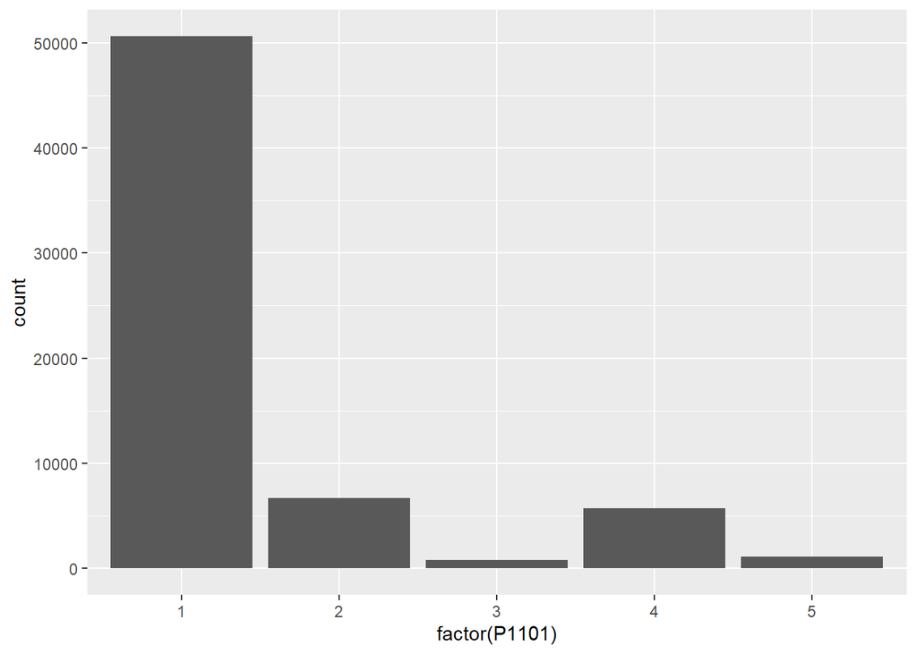

```r
ggplot(hijosxeducna, aes(x=factor(P1101))) + geom_bar()
```

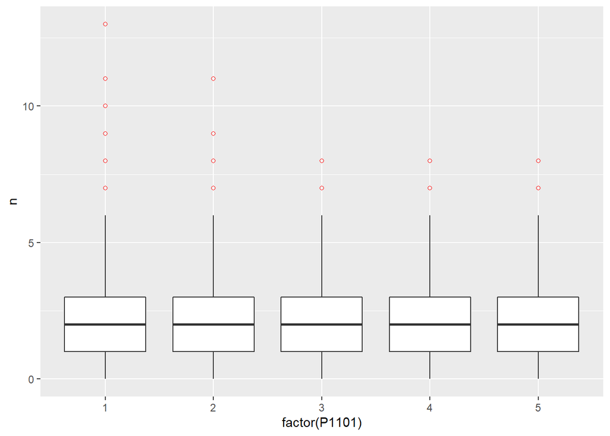

```r
ggplot(hijosxeducna, aes(x = factor(P1101), y = n)) + geom_boxplot(outlier.colour = "red", outlier.shape = 1)
```

no se considera

# Vrbls. de Fuerza de trabajo

```r
ft<- read.csv("Fuerza de trabajo.csv", sep = ";")
nombres <- names(ft)
nombres[1]<-"DIRECTORIO"
colnames(ft)<- nombres
ft$DIRECTORIO<- as.factor(ft$DIRECTORIO)
hijosxft <- merge(x = hijoscabx, y = ft, all=TRUE)
```

## P421S4: Cuidó o atendió de niños la semana pasada

Corresponde a la pregunta: **Adicional a las actividades que me informó haber realizado la semana pasada, cuales de las siguientes labores no remuneradas hizo: Cuidar o atender niños (as)?** Las respuestas son: 1. Sí 2. No

```r
hijosxftna<- hijosxft[!is.na(hijosxft$P421S4),]
tapply(hijosxftna$n, hijosxftna$P421S4, summary)
```

```
## $`1`
##    Min. 1st Qu.  Median    Mean 3rd Qu.    Max.
##   0.000   2.000   3.000   2.971   4.000  10.000
##
## $`2`
##    Min. 1st Qu.  Median    Mean 3rd Qu.    Max.
##   0.000   1.000   2.000   2.338   3.000  13.000
```

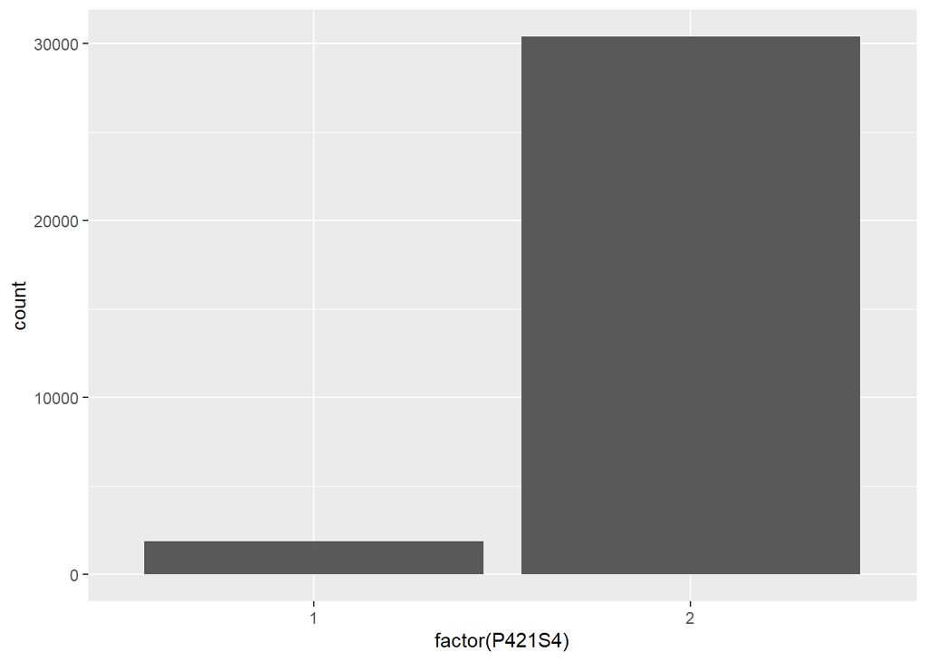

```r
ggplot(hijosxftna, aes(x=factor(P421S4))) + geom_bar()
```

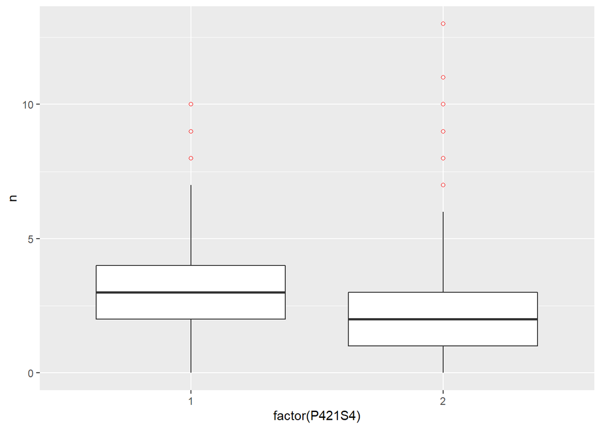

```r
ggplot(hijosxftna, aes(x = factor(P421S4), y = n)) + geom_boxplot(outlier.colour = "red", outlier.shape = 1)
```

esta no

# Vrbls. de Tecnologías de información y comunicación

```r
tic <- read.csv("Tecnologías de información y comunicación.csv", sep = ";")
nombres <- names(tic)
nombres[1]<-"DIRECTORIO"
colnames(tic)<- nombres
tic$DIRECTORIO<- as.factor(tic$DIRECTORIO)
hijosxtic <- merge(x = hijoscabx, y = tic)
```

## P1082 Posee celular

Corresponde a la pregunta: **¿ ____ tiene teléfono celular?** Las respuestas son: 1. Sí 2. No

```r
hijosxticna<- hijosxtic[!is.na(hijosxtic$P1082),]
tapply(hijosxticna$n, hijosxticna$P1082, summary)
```

```
## $`1`
##    Min. 1st Qu.  Median    Mean 3rd Qu.    Max.
##   0.000   0.000   1.000   1.423   2.000  13.000
##
## $`2`
##    Min. 1st Qu.  Median    Mean 3rd Qu.    Max.
##   0.000   1.000   2.000   2.121   3.000  13.000
```

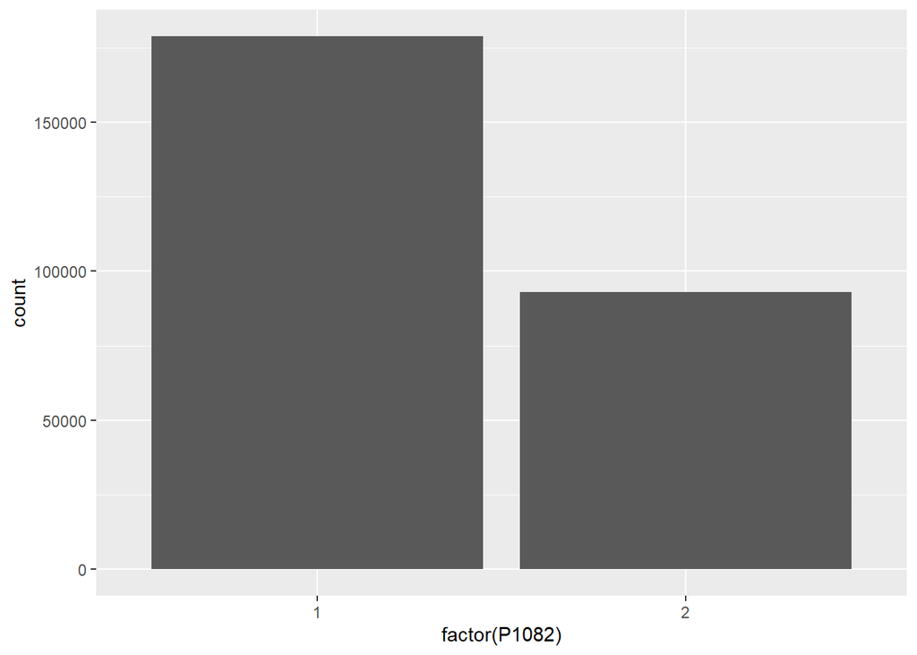

```r
ggplot(hijosxticna, aes(x=factor(P1082))) + geom_bar()
```

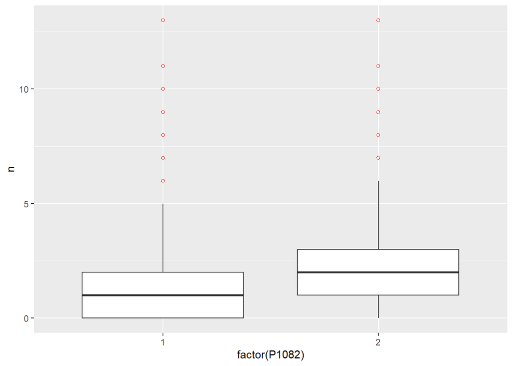

```r
ggplot(hijosxticna, aes(x = factor(P1082), y = n)) + geom_boxplot(outlier.colour = "red", outlier.shape = 1)
```

no se considera

## P1082S2 smartphones

¿ ____ tiene teléfono celular? Teléfono celular inteligente (smartphone) 1. Si 2. No Se adapta para el numero de hijos:

```r
telefonos <- tic %>% filter(P1082S2==1) %>% count(DIRECTORIO)
telefonosxtic <- merge(x = telefonos, y = tic, all = TRUE)
telefonosxtic$n[is.na(telefonosxtic$n)] <- 0
telefonosxtic<-rename(telefonosxtic, "smartf" = n)

hijosxtelefonosxtic <- merge(x = hijoscabx, y = telefonosxtic, all = TRUE)
# sum(is.na(hijosxtelefonosxtic$n))
hijosxtelefonosxtic$n[is.na(hijosxtelefonosxtic$n)] <- 0
# sum(is.na(hijosxtelefonosxtic$smartf)) no hay
```

```r
tapply(hijosxtelefonosxtic$n, hijosxtelefonosxtic$smartf, summary)
```

```
## $`0`
##    Min. 1st Qu.  Median    Mean 3rd Qu.    Max.
##   0.000   0.000   1.000   1.475   2.000  11.000
##
## $`1`
##    Min. 1st Qu.  Median    Mean 3rd Qu.    Max.
##   0.000   0.000   1.000   1.443   2.000  13.000
##
## $`2`
##    Min. 1st Qu.  Median    Mean 3rd Qu.    Max.
##   0.000   1.000   1.000   1.539   2.000  11.000
##
## $`3`
##    Min. 1st Qu.  Median    Mean 3rd Qu.    Max.
##   0.000   1.000   2.000   1.856   2.000   8.000
##
## $`4`
##    Min. 1st Qu.  Median    Mean 3rd Qu.    Max.
##   0.000   2.000   2.000   2.376   3.000  10.000
##
## $`5`
##    Min. 1st Qu.  Median    Mean 3rd Qu.    Max.
##   0.000   2.000   3.000   2.735   3.000   8.000
##
## $`6`
##    Min. 1st Qu.  Median    Mean 3rd Qu.    Max.
##   0.000   2.000   3.000   3.169   4.000   9.000
##
## $`7`
##    Min. 1st Qu.  Median    Mean 3rd Qu.    Max.
##   0.000   2.000   3.000   3.422   5.000   8.000
##
## $`8`
##    Min. 1st Qu.  Median    Mean 3rd Qu.    Max.
##   1.000   3.250   4.000   4.526   6.000   8.000
##
## $`9`
##    Min. 1st Qu.  Median    Mean 3rd Qu.    Max.
##   2.000   3.000   4.000   4.009   5.000   5.000
##
## $`10`
##    Min. 1st Qu.  Median    Mean 3rd Qu.    Max.
##   4.000   4.000   6.000   5.083   6.000   6.000
##
## $`12`
##    Min. 1st Qu.  Median    Mean 3rd Qu.    Max.
##       4       4       4       4       4       4
```

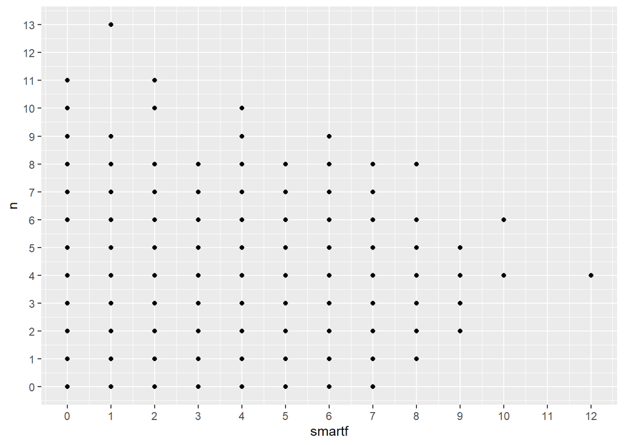

```r
ggplot(hijosxtelefonosxtic, aes(x = smartf, y = n)) + geom_point() + scale_x_continuous(breaks = seq(0,13,1))  + scale_y_continuous(breaks = seq(0,13,1))
```

# Vrbls. de Servicios del hogar

```r
sdh<- read.csv("Servicios del hogar.csv", sep = ";", dec = ",")
nombres <- names(sdh)
nombres[1]<-"DIRECTORIO"
colnames(sdh)<- nombres
sdh$DIRECTORIO<- as.factor(sdh$DIRECTORIO)
hijosxsdh <- merge(x = hijoscabx, y = sdh)
```

## P5000 cuartos

Corresponde a la pregunta: **Incluyendo sala y comedor, ¿de cuántos cuartos o piezas dispone este hogar?**

```r
tapply(hijosxsdh$n, hijosxsdh$P5000, summary)
```

```
## $`1`
##    Min. 1st Qu.  Median    Mean 3rd Qu.    Max.
##   0.000   0.000   0.000   1.005   2.000  13.000
##
## $`2`
##    Min. 1st Qu.  Median    Mean 3rd Qu.    Max.
##   0.000   0.000   1.000   1.009   2.000  13.000
##
## $`3`
##    Min. 1st Qu.  Median    Mean 3rd Qu.    Max.
##   0.000   0.000   1.000   1.126   2.000   9.000
##
## $`4`
##    Min. 1st Qu.  Median    Mean 3rd Qu.    Max.
##   0.000   0.000   1.000   1.303   2.000  11.000
##
## $`5`
##    Min. 1st Qu.  Median    Mean 3rd Qu.    Max.
##   0.000   1.000   1.000   1.517   2.000   8.000
##
## $`6`
##    Min. 1st Qu.  Median    Mean 3rd Qu.    Max.
##   0.000   1.000   1.000   1.528   2.000   8.000
##
## $`7`
##    Min. 1st Qu.  Median    Mean 3rd Qu.    Max.
##   0.000   1.000   1.000   1.566   2.000   9.000
##
## $`8`
##    Min. 1st Qu.  Median    Mean 3rd Qu.    Max.
##   0.000   1.000   2.000   1.669   2.000   8.000
##
## $`9`
##    Min. 1st Qu.  Median    Mean 3rd Qu.    Max.
##   0.000   1.000   2.000   1.762   2.000   6.000
##
## $`10`
##    Min. 1st Qu.  Median    Mean 3rd Qu.    Max.
##    1.00    1.00    1.00    1.25    1.25    2.00
##
## $`11`
##    Min. 1st Qu.  Median    Mean 3rd Qu.    Max.
##     1.0     1.5     2.0     2.0     2.5     3.0
##
## $`12`
##    Min. 1st Qu.  Median    Mean 3rd Qu.    Max.
##    0.00    0.25    0.50    0.50    0.75    1.00
##
## $`13`
##    Min. 1st Qu.  Median    Mean 3rd Qu.    Max.
##       0       0       0       0       0       0
##
## $`16`
##    Min. 1st Qu.  Median    Mean 3rd Qu.    Max.
##       0       0       0       0       0       0
```

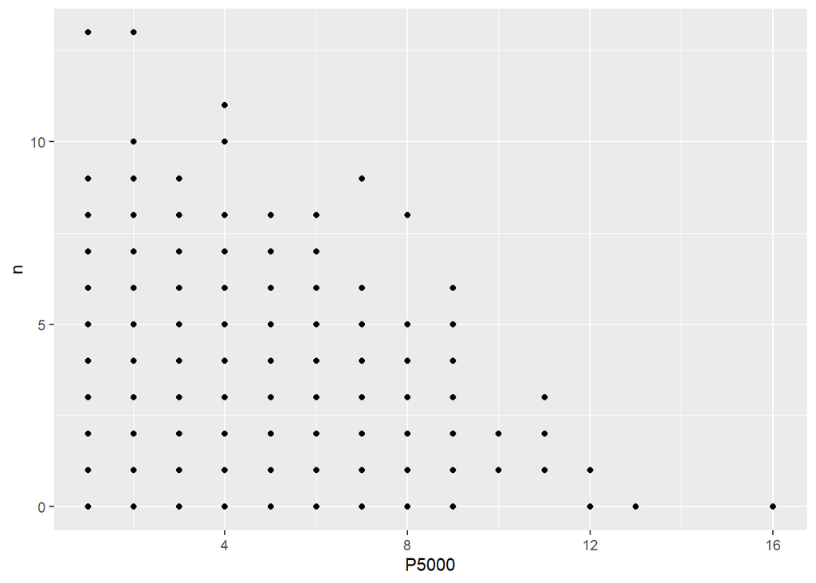

```r
ggplot(hijosxsdh, aes(x = P5000, y = n)) + geom_point()
```

```r
cor(hijosxsdh$n, hijosxsdh$P5000)
```

```
## [1] 0.1161112
```

## P3000

Corresponde a la pregunta: **¿Cuál es la fuente de iluminación principal en la vivienda?** Las respuestas son: 1. Energía eléctrica 2. Lámpara de Gas Propano 3. Lámpara de Kereosene, petróleo, gasolina 4. Lámpara de pilas o baterias 5. Velas

```r
hijosxsdhna<- hijosxsdh[!is.na(hijosxsdh$P3000),]
tapply(hijosxsdhna$n, hijosxsdhna$P3000, summary)
```

```
## $`1`
##    Min. 1st Qu.  Median    Mean 3rd Qu.    Max.
##   0.000   0.000   1.000   1.163   2.000  13.000
##
## $`2`
##    Min. 1st Qu.  Median    Mean 3rd Qu.    Max.
##   0.000   0.000   1.000   1.196   2.000   4.000
##
## $`3`
##    Min. 1st Qu.  Median    Mean 3rd Qu.    Max.
##   0.000   0.000   0.000   1.064   2.000   8.000
##
## $`4`
##    Min. 1st Qu.  Median    Mean 3rd Qu.    Max.
##   0.000   0.000   1.000   1.352   2.000   9.000
##
## $`5`
##    Min. 1st Qu.  Median    Mean 3rd Qu.    Max.
##   0.000   0.000   1.000   1.289   2.000   9.000
```

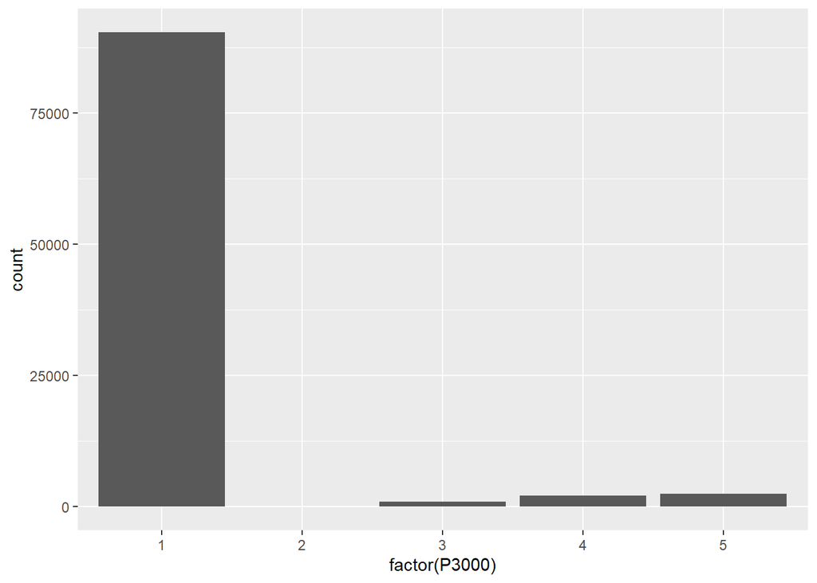

```r
ggplot(hijosxsdhna, aes(x=factor(P3000))) + geom_bar()
```

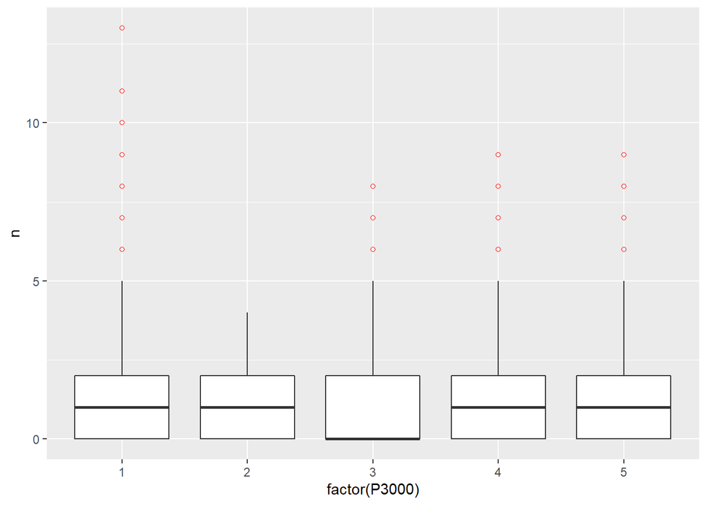

```r
ggplot(hijosxsdhna, aes(x = factor(P3000), y = n)) + geom_boxplot(outlier.colour = "red", outlier.shape = 1)
```

## P5024

Corresponde a la pregunta: **¿De cuántos servicios sanitarios o inodoros dispone este hogar?**

```r
tapply(hijosxsdh$n, hijosxsdh$P5024, summary)
```

```
## $`1`
##    Min. 1st Qu.  Median    Mean 3rd Qu.    Max.
##   0.000   0.000   1.000   1.159   2.000  13.000
##
## $`2`
##    Min. 1st Qu.  Median    Mean 3rd Qu.    Max.
##   0.000   0.000   1.000   1.047   2.000   8.000
##
## $`3`
##    Min. 1st Qu.  Median    Mean 3rd Qu.    Max.
##  0.0000  0.0000  1.0000  0.9247  2.0000  6.0000
##
## $`4`
##    Min. 1st Qu.  Median    Mean 3rd Qu.    Max.
##  0.0000  0.0000  1.0000  0.9896  2.0000  4.0000
##
## $`5`
##    Min. 1st Qu.  Median    Mean 3rd Qu.    Max.
##  0.0000  0.0000  1.0000  0.9325  2.0000  4.0000
##
## $`6`
##    Min. 1st Qu.  Median    Mean 3rd Qu.    Max.
##   0.000   0.000   1.000   1.107   2.000   3.000
##
## $`7`
##    Min. 1st Qu.  Median    Mean 3rd Qu.    Max.
##  0.0000  0.0000  0.0000  0.4118  1.0000  1.0000
##
## $`8`
##    Min. 1st Qu.  Median    Mean 3rd Qu.    Max.
##   0.000   0.000   1.000   1.188   2.000   5.000
##
## $`9`
##    Min. 1st Qu.  Median    Mean 3rd Qu.    Max.
##     1.0     1.5     2.0     2.0     2.5     3.0
##
## $`10`
##    Min. 1st Qu.  Median    Mean 3rd Qu.    Max.
##       0       0       0       0       0       0
##
## $`11`
##    Min. 1st Qu.  Median    Mean 3rd Qu.    Max.
##       1       1       1       1       1       1
##
## $`12`
##    Min. 1st Qu.  Median    Mean 3rd Qu.    Max.
##       0       0       0       0       0       0
```

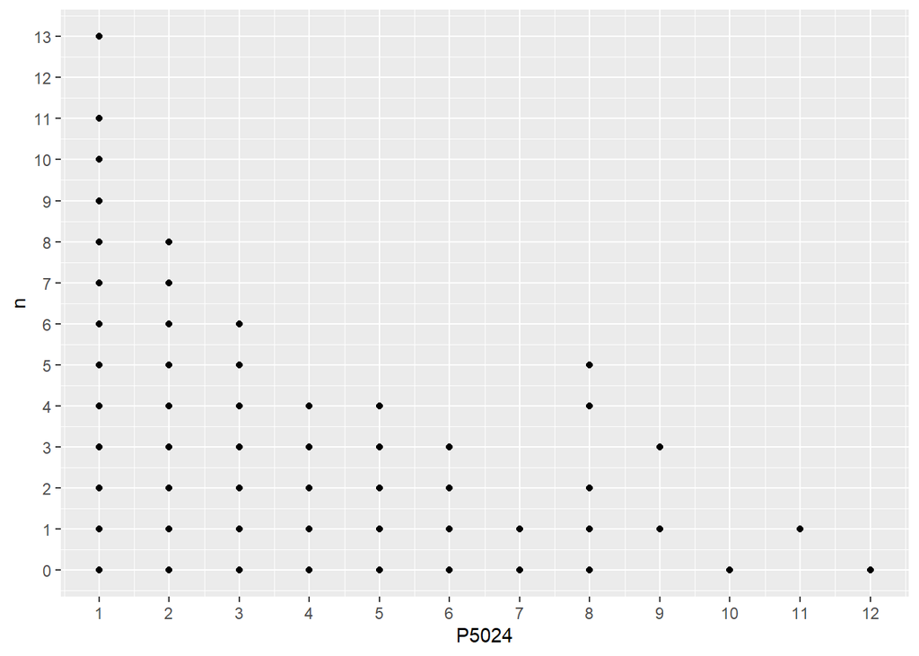

```r
ggplot(hijosxsdh, aes(x = P5024, y = n)) + geom_point() + scale_x_continuous(breaks = seq(0,13,1))  + scale_y_continuous(breaks = seq(0,13,1))
```

```r
with(hijosxsdh[!is.na(hijosxsdh$P5024),],cor(n, P5024))
```

```
## [1] -0.04037156
```

## P8534

Corresponde a la pregunta: **El hogar tiene cocina? (espacio exclusivo para preparar alimentos)** 1. Sí 2. No

```r
sum(is.na(hijosxsdh$P8534))/length(hijosxsdh$P8534)
```

```
## [1] 0.9717249
```

```r
hijosxsdhna<- hijosxsdh[!is.na(hijosxsdh$P8534),]
tapply(hijosxsdhna$n, hijosxsdhna$P8534, summary)
```

```
## $`1`
##    Min. 1st Qu.  Median    Mean 3rd Qu.    Max.
##  0.0000  0.0000  0.0000  0.2467  0.0000  5.0000
##
## $`2`
##    Min. 1st Qu.  Median    Mean 3rd Qu.    Max.
##  0.0000  0.0000  0.0000  0.3128  0.0000  7.0000
```

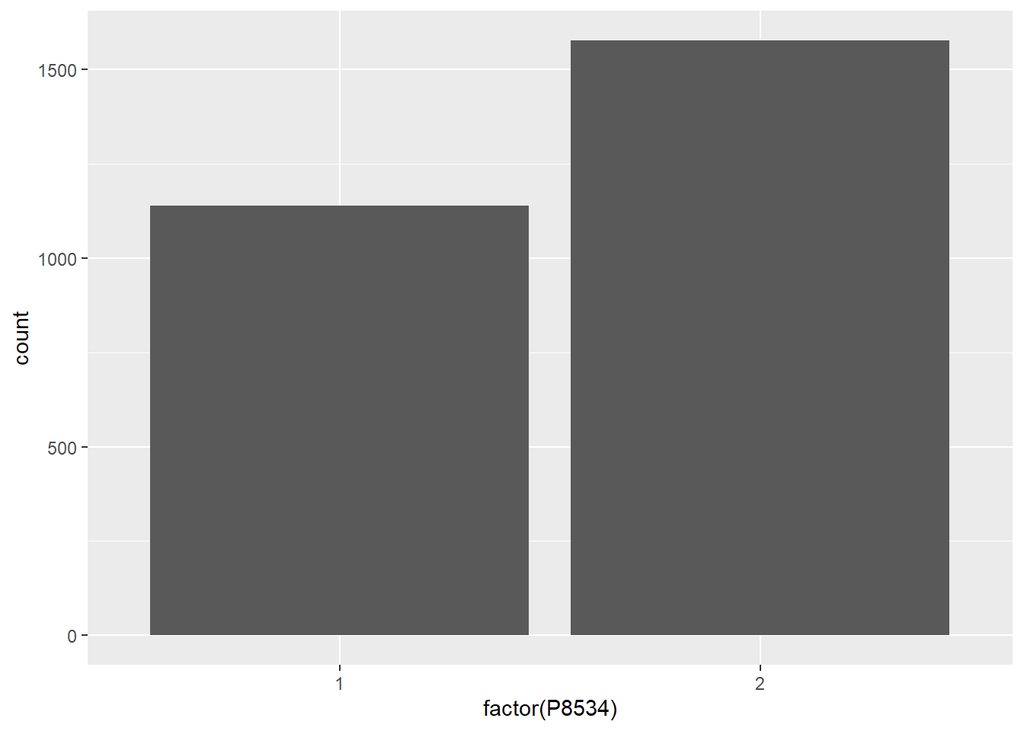

```r
ggplot(hijosxsdhna, aes(x=factor(P8534))) + geom_bar()
```

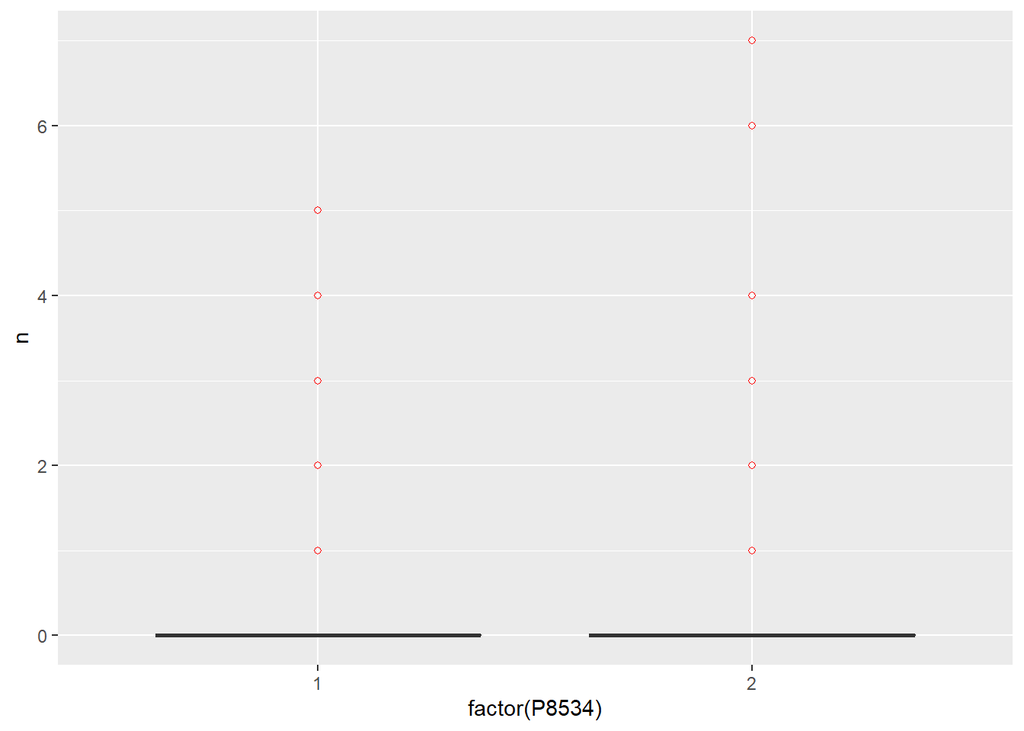

```r
ggplot(hijosxsdhna, aes(x = factor(P8534), y = n)) + geom_boxplot(outlier.colour = "red", outlier.shape = 1)
```

muchos outliers

#P5013S1 Cantidad de comidas Con qué frecuencia preparan alimentos en este hogar? Veces al día

```r
summary(hijosxsdh$P5013S1)
```

```
##    Min. 1st Qu.  Median    Mean 3rd Qu.    Max.    NA's
##   1.000   2.000   3.000   2.517   3.000  20.000    3764
```

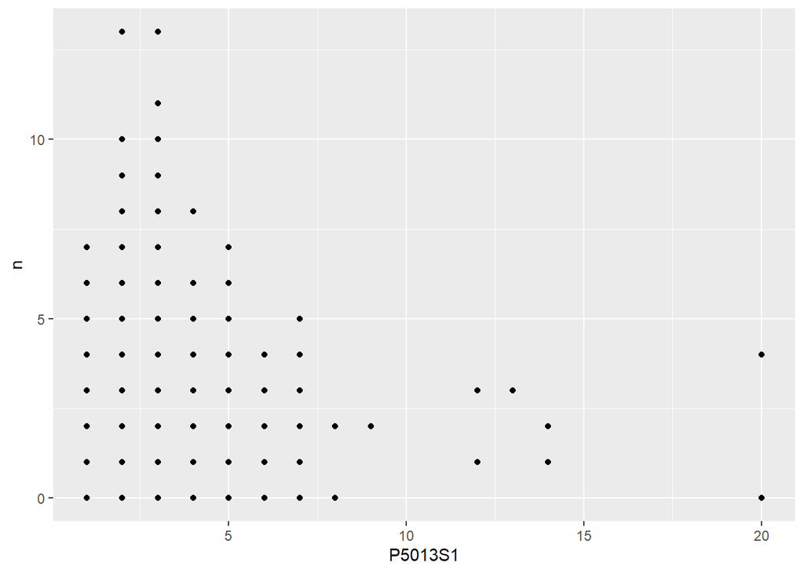

```r
ggplot(hijosxsdh, aes(x = P5013S1, y = n)) + geom_point()
```

```r
with(hijosxsdh[!is.na(hijosxsdh$P5013S1),],cor(n, P5013S1))
```

```
## [1] 0.1419059
```

## I_HOGAR

Corresponde a la pregunta: **Ingreso mensual total del hogar**

```r
summary(hijosxsdh$I_HOGAR)
```

```
##      Min.   1st Qu.    Median      Mean   3rd Qu.      Max.
##         0    525833   1016667   1716916   1861449 284600000
```

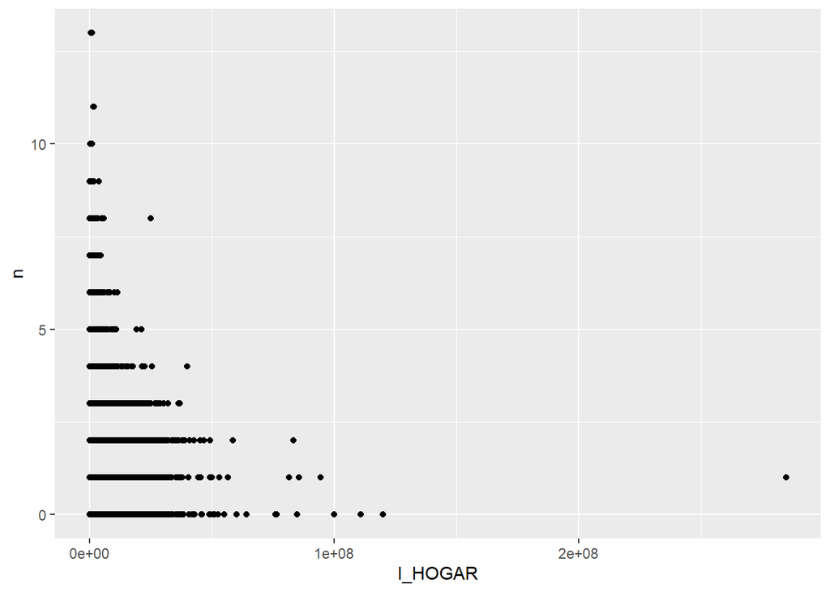

```r
ggplot(hijosxsdh, aes(x = I_HOGAR, y = n)) + geom_point()
```

```r
cor(hijosxsdh$n, hijosxsdh$I_HOGAR)
```

```
## [1] 0.01224906
```

## I_UGASTO

Corresponde a la pregunta: **Ingreso mensual total de la unidad de gasto**

```r
summary(hijosxsdh$I_UGASTO)
```

```
##      Min.   1st Qu.    Median      Mean   3rd Qu.      Max.
##         0    525000   1015000   1711424   1856399 284600000
```

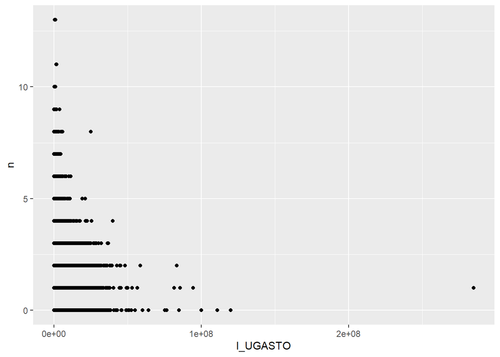

```r
ggplot(hijosxsdh, aes(x = I_UGASTO, y = n)) + geom_point()
```

```r
cor(hijosxsdh$n, hijosxsdh$I_UGASTO)
```

```
## [1] 0.0129907
```

## PERCAPITA

Corresponde a la pregunta: **Ingreso per-cápita**

```r
summary(hijosxsdh$PERCAPITA)
```

```
##      Min.   1st Qu.    Median      Mean   3rd Qu.      Max.
##         0    192333    365833    705531    720000 120000000
```

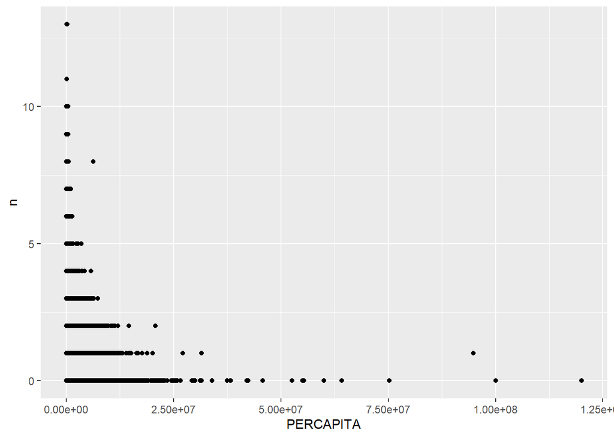

```r
ggplot(hijosxsdh, aes(x = PERCAPITA, y = n)) + geom_point()
```

```r
cor(hijosxsdh$n, hijosxsdh$PERCAPITA)
```

```
## [1] -0.1633069
```

no creo

## I_OU

Corresponde a la pregunta: **Ingreso mensual total de la otra unidad de gasto**

```r
summary(hijosxsdh$I_OU)
```

```
##    Min. 1st Qu.  Median    Mean 3rd Qu.    Max.
##       0       0       0    5492       0 6740000
```

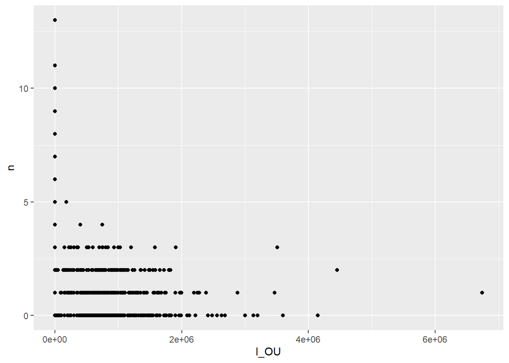

```r
ggplot(hijosxsdh, aes(x = I_OU, y = n)) + geom_point()
```

```r
cor(hijosxsdh$n, hijosxsdh$I_OU)
```

```
## [1] -0.02402787
```

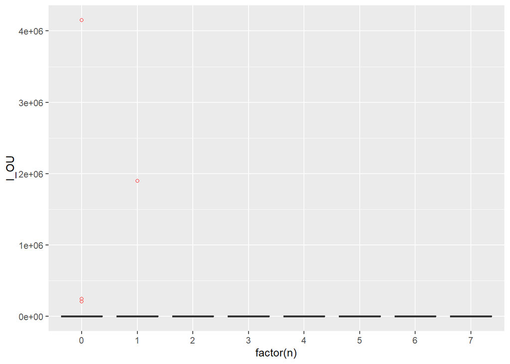

```r
ggplot(hijosxsdhna, aes(x = factor(n), y = I_OU)) + geom_boxplot(outlier.colour = "red", outlier.shape = 1)
```

## CANT_PERSONAS_HOGAR

Corresponde a la pregunta: **Cantidad de personas en el hogar**

```r
tapply(hijosxsdh$n, hijosxsdh$CANT_PERSONAS_HOGAR, summary)
```

```
## $`1`
##    Min. 1st Qu.  Median    Mean 3rd Qu.    Max.
## 0.00000 0.00000 0.00000 0.03736 0.00000 7.00000
##
## $`2`
##    Min. 1st Qu.  Median    Mean 3rd Qu.    Max.
##  0.0000  0.0000  0.0000  0.3538  1.0000 10.0000
##
## $`3`
##    Min. 1st Qu.  Median    Mean 3rd Qu.    Max.
##   0.000   1.000   1.000   1.112   1.000  10.000
##
## $`4`
##    Min. 1st Qu.  Median    Mean 3rd Qu.    Max.
##   0.000   2.000   2.000   1.858   2.000  10.000
##
## $`5`
##    Min. 1st Qu.  Median    Mean 3rd Qu.    Max.
##   0.000   2.000   3.000   2.457   3.000  13.000
##
## $`6`
##    Min. 1st Qu.  Median    Mean 3rd Qu.    Max.
##   0.000   2.000   3.000   2.928   4.000  10.000
##
## $`7`
##    Min. 1st Qu.  Median    Mean 3rd Qu.    Max.
##    0.00    2.00    3.00    3.37    5.00    7.00
##
## $`8`
##    Min. 1st Qu.  Median    Mean 3rd Qu.    Max.
##   0.000   2.000   4.000   3.811   6.000  13.000
##
## $`9`
##    Min. 1st Qu.  Median    Mean 3rd Qu.    Max.
##    0.00    2.00    4.00    3.97    6.00    8.00
##
## $`10`
##    Min. 1st Qu.  Median    Mean 3rd Qu.    Max.
##   0.000   3.000   4.000   4.182   5.500   8.000
##
```

[output cut: 20 more lines]

```
## $`16`
##    Min. 1st Qu.  Median    Mean 3rd Qu.    Max.
##     2.0     3.0     5.0     5.4     6.0    11.0
##
## $`17`
##    Min. 1st Qu.  Median    Mean 3rd Qu.    Max.
##   3.000   4.000   5.000   4.667   5.500   6.000
##
## $`18`
##    Min. 1st Qu.  Median    Mean 3rd Qu.    Max.
##     2.0     2.5     3.0     3.0     3.5     4.0
##
## $`19`
##    Min. 1st Qu.  Median    Mean 3rd Qu.    Max.
##     4.0     4.5     5.0     5.0     5.5     6.0
```

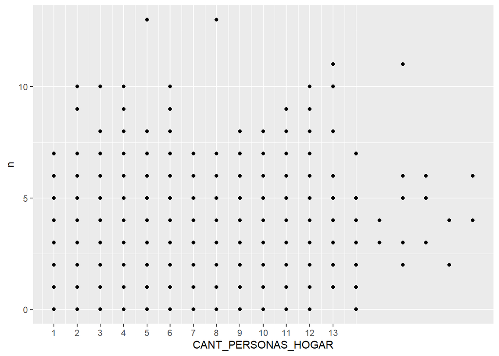

```r
ggplot(hijosxsdh, aes(x = CANT_PERSONAS_HOGAR , y = n)) + geom_point() + scale_x_continuous(breaks = seq(0,13,1))
```

```r
cor(hijosxsdh$n, hijosxsdh$CANT_PERSONAS_HOGAR)
```

```
## [1] 0.7694506
```

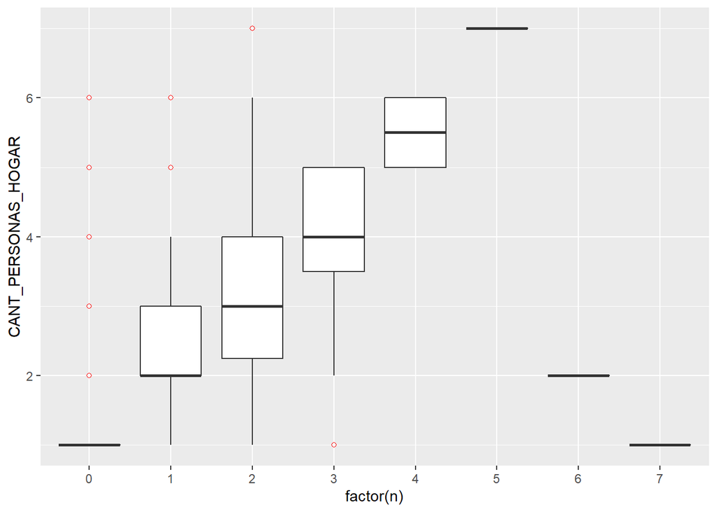

```r
ggplot(hijosxsdhna, aes(x = factor(n), y = CANT_PERSONAS_HOGAR)) + geom_boxplot(outlier.colour = "red", outlier.shape = 1)
```

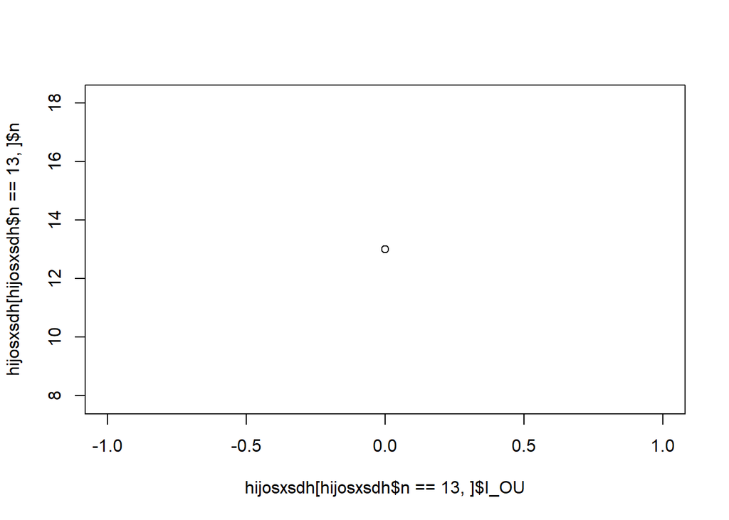

```r
plot(hijosxsdh[hijosxsdh$n==13,]$I_OU,hijosxsdh[hijosxsdh$n==13,]$n)
```